# Xam Balların Çevrilməsi: Standart Balların Hesablanması

Klassik Test Nəzəriyyəsi - Norma və Standartlaşma

Klassik Test Nəzəriyyəsi Kursu

2025-07-18

## 0.1 Dərsin Məqsədləri

✓ Xam balları standart ballara çevirmənin əsaslarını öyrənmək  
✓ Z-bal, T-bal və Stanin ballarının hesablanmasını mənimsəmək  
✓ Müxtəlif standart bal sistemlərinin xüsusiyyətlərini anlamaq  
✓ R-da bal çevrilməsi funksiyalarını yazmaq və istifadə etmək  
✓ Praktik şəraitlərdə uyğun bal sistemi seçmək

## 0.2 Əvvəlki Dərsdən Xatırladıqlarımız

**Dərs 15-də öyrəndiklərimiz:** - Test komponentlərinin optimallaşdırılması - Bənd seçimi alqoritmləri - Homojenlik və heterojenlik balansı - Test keyfiyyət qiymətləndirməsi

# 1 Standartlaşmanın Zərurəti

## 1.1 Xam Balların Problemləri

```r
# Nümunə test məlumatları
set.seed(123)
n_students <- 100

# Üç fərqli test - fərqli orta və variasiya
test_math <- round(rnorm(n_students, mean = 75, sd = 12), 1)
test_verbal <- round(rnorm(n_students, mean = 520, sd = 85), 0)
test_science <- round(rnorm(n_students, mean = 28, sd = 6), 1)

# Xam ballar data frame
raw_scores <- data.frame(
  Student_ID = 1:n_students,
  Riyaziyyat = test_math,
  Verbal = test_verbal,
  Elm = test_science
)

# Təsviri statistikalar
descriptive_stats <- data.frame(
  Test = c("Riyaziyyat", "Verbal", "Elm"),
  Orta = c(mean(raw_scores$Riyaziyyat), mean(raw_scores$Verbal), mean(raw_scores$Elm)),
  SD = c(sd(raw_scores$Riyaziyyat), sd(raw_scores$Verbal), sd(raw_scores$Elm)),
  Min = c(min(raw_scores$Riyaziyyat), min(raw_scores$Verbal), min(raw_scores$Elm)),
  Max = c(max(raw_scores$Riyaziyyat), max(raw_scores$Verbal), max(raw_scores$Elm))
)

kable(descriptive_stats, caption = "Xam Balların Təsviri Statistikaları", digits = 1)
```

Xam Balların Təsviri Statistikaları

| Test | Orta | SD | Min | Max |
| --- | --- | --- | --- | --- |
| Riyaziyyat | 76.1 | 10.9 | 47.3 | 101.2 |
| Verbal | 510.8 | 82.2 | 345.0 | 795.0 |
| Elm | 28.7 | 5.7 | 17.5 | 41.8 |

```r
# Müqayisə problemi nümunəsi
comparison_example <- data.frame(
  Tələbə = c("Ali", "Ayşə", "Elman"),
  Riyaziyyat = c(82, 78, 85),
  Verbal = c(580, 510, 625),
  Elm = c(31, 26, 34)
)

kable(comparison_example, caption = "Müqayisə Problemi: Hansı Tələbə Daha Yaxşıdır?")
```

Müqayisə Problemi: Hansı Tələbə Daha Yaxşıdır?

| Tələbə | Riyaziyyat | Verbal | Elm |
| --- | --- | --- | --- |
| Ali | 82 | 580 | 31 |
| Ayşə | 78 | 510 | 26 |
| Elman | 85 | 625 | 34 |

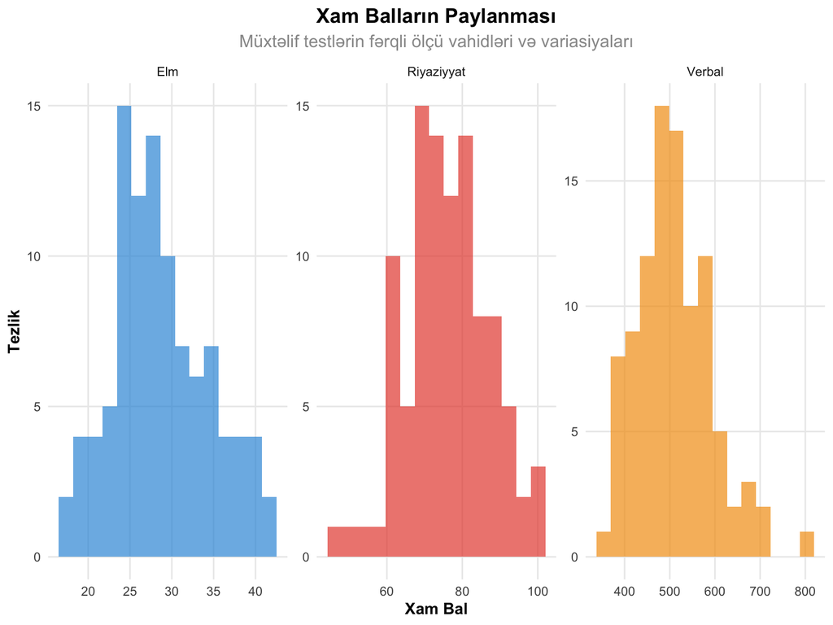

```r
# Xam balların paylanması
raw_long <- raw_scores %>%
  select(-Student_ID) %>%
  pivot_longer(everything(), names_to = "Test", values_to = "Xam_Bal")

ggplot(raw_long, aes(x = Xam_Bal, fill = Test)) +
  geom_histogram(alpha = 0.7, bins = 15) +
  facet_wrap(~Test, scales = "free") +
  scale_fill_manual(values = colors_basic[1:3]) +
  labs(title = "Xam Balların Paylanması",
       subtitle = "Müxtəlif testlərin fərqli ölçü vahidləri və variasiyaları",
       x = "Xam Bal", y = "Tezlik") +
  theme_clean() +
  theme(legend.position = "none")
```

## 1.2 Standartlaşmanın Üstünlükləri

```r
# Standartlaşmanın faydaları
benefits <- data.frame(
  Üstünlük = c("Müqayisə Edilə Bilən", "İnterpretasiya Asanlığı", "Norma İstinadı",
                "Statistik Əməliyyat", "Qrafik Təqdimat", "Profil Analizi"),
  İzah = c("Fərqli testlər eyni miqyasda", "Standart mənalar mövcud", "Qrupa görə mövqe",
           "Riyazi əməliyyatlar asanlaşır", "Eyni miqyasda vizuallaşma", "Çoxlu test müqayisəsi"),
  Nümunə = c("Z = 1.5 vs Z = 0.8", "T = 60 = ortadan yuxarı", "95%-lik göstərici",
             "Orta hesablanması", "Profil diaqramı", "Güclü/zəif sahələr")
)

kable(benefits, caption = "Standartlaşmanın Üstünlükləri")
```

Standartlaşmanın Üstünlükləri

| Üstünlük | İzah | Nümunə |
| --- | --- | --- |
| Müqayisə Edilə Bilən | Fərqli testlər eyni miqyasda | Z = 1.5 vs Z = 0.8 |
| İnterpretasiya Asanlığı | Standart mənalar mövcud | T = 60 = ortadan yuxarı |
| Norma İstinadı | Qrupa görə mövqe | 95%-lik göstərici |
| Statistik Əməliyyat | Riyazi əməliyyatlar asanlaşır | Orta hesablanması |
| Qrafik Təqdimat | Eyni miqyasda vizuallaşma | Profil diaqramı |
| Profil Analizi | Çoxlu test müqayisəsi | Güclü/zəif sahələr |

# 2 Z-Ballar

## 2.1 Z-Balların Əsasları

**Z-bal** - xam balın orta qiymətdən neçə standart sapma fərqləndiyi göstərir.

### 2.1.1 **Z = (X - M) / SD**

Bu formulada: - **Z** = Standart bal (Z-score) - **X** = Xam bal (raw score) - **M** = Orta qiymət (mean) - **SD** = Standart sapma (standard deviation)

```r
# Z-balların hesablanması funksiyası
calculate_z_scores <- function(raw_scores) {
  mean_score <- mean(raw_scores, na.rm = TRUE)
  sd_score <- sd(raw_scores, na.rm = TRUE)
  z_scores <- (raw_scores - mean_score) / sd_score
  return(z_scores)
}

# Hər test üçün Z-ballar
raw_scores$Z_Riyaziyyat <- round(calculate_z_scores(raw_scores$Riyaziyyat), 2)
raw_scores$Z_Verbal <- round(calculate_z_scores(raw_scores$Verbal), 2)
raw_scores$Z_Elm <- round(calculate_z_scores(raw_scores$Elm), 2)

# İlk 10 tələbənin nəticələri
kable(head(raw_scores, 10), caption = "Xam Ballar və Z-Ballar", digits = 2)
```

Xam Ballar və Z-Ballar

| Student_ID | Riyaziyyat | Verbal | Elm | Z_Riyaziyyat | Z_Verbal | Z_Elm |
| --- | --- | --- | --- | --- | --- | --- |
| 1 | 68.3 | 460 | 41.2 | -0.71 | -0.62 | 2.19 |
| 2 | 72.2 | 542 | 35.9 | -0.36 | 0.38 | 1.26 |
| 3 | 93.7 | 499 | 26.4 | 1.61 | -0.14 | -0.41 |
| 4 | 75.8 | 490 | 31.3 | -0.03 | -0.25 | 0.45 |
| 5 | 76.6 | 439 | 25.5 | 0.05 | -0.87 | -0.57 |
| 6 | 95.6 | 516 | 25.1 | 1.78 | 0.06 | -0.64 |
| 7 | 80.5 | 453 | 23.3 | 0.40 | -0.70 | -0.95 |
| 8 | 59.8 | 378 | 24.4 | -1.49 | -1.62 | -0.76 |
| 9 | 66.8 | 488 | 37.9 | -0.85 | -0.28 | 1.61 |
| 10 | 69.7 | 598 | 27.7 | -0.58 | 1.06 | -0.18 |

```r
# Z-balların xüsusiyyətləri
z_properties <- data.frame(
  Xüsusiyyət = c("Orta", "Standart Sapma", "Aralıq", "Paylanma Forması",
                 "Vahid", "İnterpretasiya"),
  Z_Bal = c("0", "1", "-3 to +3 (əksəriyyət)", "Orijinala eyni",
            "Standart sapma", "0 = orta, ±1 = tipik"),
  İzah = c("Həmişə sıfır", "Həmişə bir", "99.7% məlumat", "Forma saxlanılır",
           "Qiymətsiz rəqəm", "Müsbət/mənfi mənalı")
)

kable(z_properties, caption = "Z-Balların Fundamental Xüsusiyyətləri")
```

Z-Balların Fundamental Xüsusiyyətləri

| Xüsusiyyət | Z_Bal | İzah |
| --- | --- | --- |
| Orta | 0 | Həmişə sıfır |
| Standart Sapma | 1 | Həmişə bir |
| Aralıq | -3 to +3 (əksəriyyət) | 99.7% məlumat |
| Paylanma Forması | Orijinala eyni | Forma saxlanılır |
| Vahid | Standart sapma | Qiymətsiz rəqəm |
| İnterpretasiya | 0 = orta, ±1 = tipik | Müsbət/mənfi mənalı |

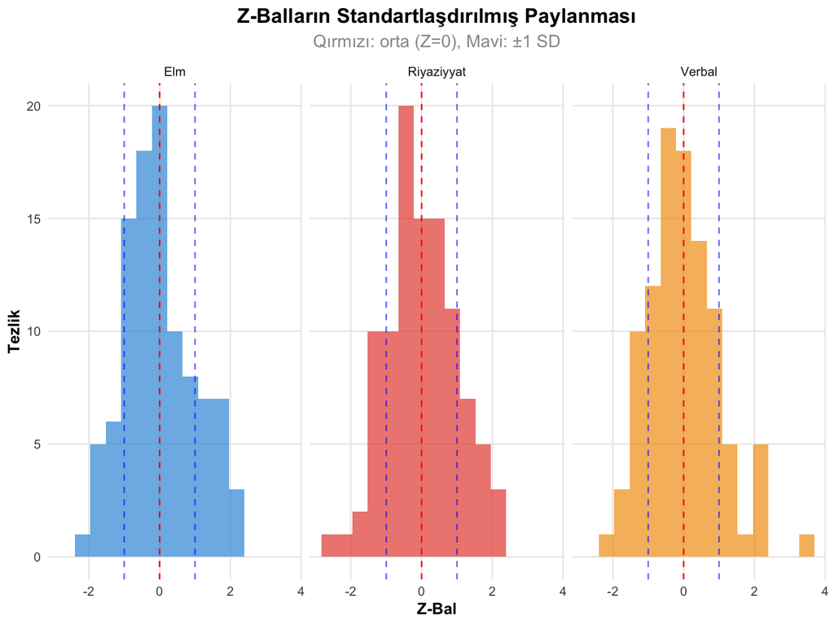

```r
# Z-balların paylanması
z_scores_long <- raw_scores %>%
  select(Student_ID, Z_Riyaziyyat, Z_Verbal, Z_Elm) %>%
  pivot_longer(cols = starts_with("Z_"), names_to = "Test", values_to = "Z_Score") %>%
  mutate(Test = gsub("Z_", "", Test))

ggplot(z_scores_long, aes(x = Z_Score, fill = Test)) +
  geom_histogram(alpha = 0.7, bins = 15) +
  facet_wrap(~Test) +
  geom_vline(xintercept = 0, linetype = "dashed", color = "red") +
  geom_vline(xintercept = c(-1, 1), linetype = "dashed", color = "blue", alpha = 0.6) +
  scale_fill_manual(values = colors_basic[1:3]) +
  labs(title = "Z-Balların Standartlaşdırılmış Paylanması",
       subtitle = "Qırmızı: orta (Z=0), Mavi: ±1 SD",
       x = "Z-Bal", y = "Tezlik") +
  theme_clean() +
  theme(legend.position = "none")
```

```r
# Z-bal interpretasiya cədvəli
z_interpretation <- data.frame(
  Z_Aralığı = c("Z ≥ +2.0", "+1.0 ≤ Z < +2.0", "-1.0 ≤ Z < +1.0",
                "-2.0 ≤ Z < -1.0", "Z < -2.0"),
  İnterpretasiya = c("Çox Yüksək", "Yüksək", "Orta", "Aşağı", "Çox Aşağı"),
  Təxmini_Faiz = c("2.5%", "13.5%", "68%", "13.5%", "2.5%"),
  Performans_Səviyyəsi = c("Üstün", "Ortadan Yuxarı", "Tipik", "Ortadan Aşağı", "Zəif")
)

kable(z_interpretation, caption = "Z-Balların İnterpretasiya Cədvəli")
```

Z-Balların İnterpretasiya Cədvəli

| Z_Aralığı | İnterpretasiya | Təxmini_Faiz | Performans_Səviyyəsi |
| --- | --- | --- | --- |
| Z ≥ +2.0 | Çox Yüksək | 2.5% | Üstün |
| +1.0 ≤ Z < +2.0 | Yüksək | 13.5% | Ortadan Yuxarı |
| -1.0 ≤ Z < +1.0 | Orta | 68% | Tipik |
| -2.0 ≤ Z < -1.0 | Aşağı | 13.5% | Ortadan Aşağı |
| Z < -2.0 | Çox Aşağı | 2.5% | Zəif |

## 2.2 Z-Balların Praktik Tətbiqi

```r
# Konkret nümunələr
specific_examples <- comparison_example
specific_examples$Z_Riyaziyyat <- round((specific_examples$Riyaziyyat - mean(raw_scores$Riyaziyyat)) /
                                       sd(raw_scores$Riyaziyyat), 2)
specific_examples$Z_Verbal <- round((specific_examples$Verbal - mean(raw_scores$Verbal)) /
                                   sd(raw_scores$Verbal), 2)
specific_examples$Z_Elm <- round((specific_examples$Elm - mean(raw_scores$Elm)) /
                                sd(raw_scores$Elm), 2)

kable(specific_examples, caption = "Konkret Tələbələr üçün Z-Ballar", digits = 2)
```

Konkret Tələbələr üçün Z-Ballar

| Tələbə | Riyaziyyat | Verbal | Elm | Z_Riyaziyyat | Z_Verbal | Z_Elm |
| --- | --- | --- | --- | --- | --- | --- |
| Ali | 82 | 580 | 31 | 0.54 | 0.84 | 0.40 |
| Ayşə | 78 | 510 | 26 | 0.17 | -0.01 | -0.48 |
| Elman | 85 | 625 | 34 | 0.81 | 1.39 | 0.93 |

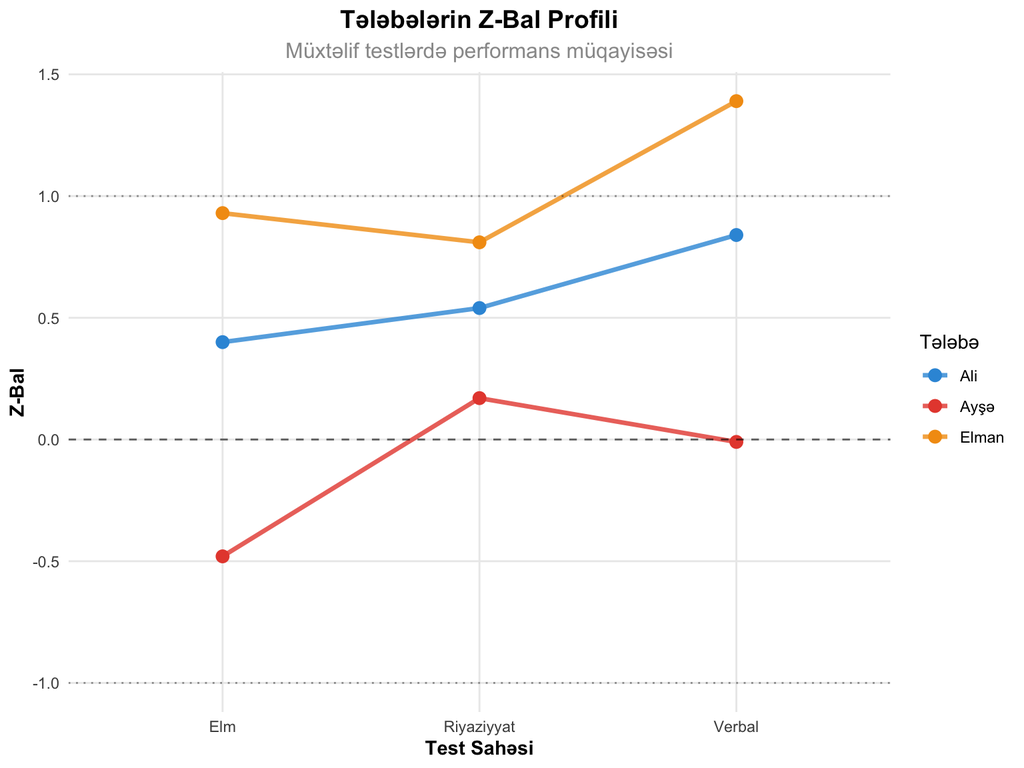

```r
# Profil analizi
profile_data <- specific_examples %>%
  select(Tələbə, Z_Riyaziyyat, Z_Verbal, Z_Elm) %>%
  pivot_longer(cols = starts_with("Z_"), names_to = "Test", values_to = "Z_Score") %>%
  mutate(Test = gsub("Z_", "", Test))

ggplot(profile_data, aes(x = Test, y = Z_Score, color = Tələbə, group = Tələbə)) +
  geom_line(size = 1.2, alpha = 0.8) +
  geom_point(size = 3) +
  geom_hline(yintercept = 0, linetype = "dashed", alpha = 0.6) +
  geom_hline(yintercept = c(-1, 1), linetype = "dotted", alpha = 0.4) +
  scale_color_manual(values = colors_basic[1:3]) +
  labs(title = "Tələbələrin Z-Bal Profili",
       subtitle = "Müxtəlif testlərdə performans müqayisəsi",
       x = "Test Sahəsi", y = "Z-Bal", color = "Tələbə") +
  theme_clean()
```

# 3 T-Ballar

## 3.1 T-Balların Xüsusiyyətləri

**T-bal** - Z-balın daha praktik forması: orta = 50, SD = 10

### 3.1.1 **T = 50 + 10Z**

Bu formulada: - **T** = T-bal - **Z** = Z-bal - **50** = T-balların ortası - **10** = T-balların standart sapması

```r
# T-balların hesablanması funksiyası
calculate_t_scores <- function(raw_scores) {
  z_scores <- calculate_z_scores(raw_scores)
  t_scores <- 50 + 10 * z_scores
  return(t_scores)
}

# Hər test üçün T-ballar
raw_scores$T_Riyaziyyat <- round(calculate_t_scores(raw_scores$Riyaziyyat), 0)
raw_scores$T_Verbal <- round(calculate_t_scores(raw_scores$Verbal), 0)
raw_scores$T_Elm <- round(calculate_t_scores(raw_scores$Elm), 0)

# T-balların xüsusiyyətləri
t_properties <- data.frame(
  Xüsusiyyət = c("Orta", "Standart Sapma", "Tipik Aralıq", "Mənfi Dəyər",
                 "Ondalık", "İnterpretasiya"),
  T_Bal = c("50", "10", "20-80", "Çox nadir", "Adətən yox", "50 = orta"),
  Z_Bal = c("0", "1", "-3 to +3", "Tez-tez", "Həmişə", "0 = orta"),
  Praktiklik = c("Daha yaxşı", "Daha yaxşı", "Daha yaxşı", "Üstün", "Üstün", "Eyni")
)

kable(t_properties, caption = "T-Bal vs Z-Bal Müqayisəsi")
```

T-Bal vs Z-Bal Müqayisəsi

| Xüsusiyyət | T_Bal | Z_Bal | Praktiklik |
| --- | --- | --- | --- |
| Orta | 50 | 0 | Daha yaxşı |
| Standart Sapma | 10 | 1 | Daha yaxşı |
| Tipik Aralıq | 20-80 | -3 to +3 | Daha yaxşı |
| Mənfi Dəyər | Çox nadir | Tez-tez | Üstün |
| Ondalık | Adətən yox | Həmişə | Üstün |
| İnterpretasiya | 50 = orta | 0 = orta | Eyni |

```r
# Konkret nümunələr
specific_examples$T_Riyaziyyat <- round(50 + 10 * specific_examples$Z_Riyaziyyat, 0)
specific_examples$T_Verbal <- round(50 + 10 * specific_examples$Z_Verbal, 0)
specific_examples$T_Elm <- round(50 + 10 * specific_examples$Z_Elm, 0)

kable(specific_examples, caption = "Z-Bal və T-Bal Müqayisəsi")
```

Z-Bal və T-Bal Müqayisəsi

| Tələbə | Riyaziyyat | Verbal | Elm | Z_Riyaziyyat | Z_Verbal | Z_Elm | T_Riyaziyyat | T_Verbal | T_Elm |
| --- | --- | --- | --- | --- | --- | --- | --- | --- | --- |
| Ali | 82 | 580 | 31 | 0.54 | 0.84 | 0.40 | 55 | 58 | 54 |
| Ayşə | 78 | 510 | 26 | 0.17 | -0.01 | -0.48 | 52 | 50 | 45 |
| Elman | 85 | 625 | 34 | 0.81 | 1.39 | 0.93 | 58 | 64 | 59 |

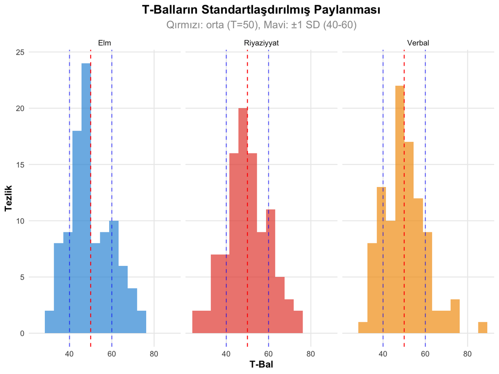

```r
# T-balların paylanması
t_scores_long <- raw_scores %>%
  select(Student_ID, T_Riyaziyyat, T_Verbal, T_Elm) %>%
  pivot_longer(cols = starts_with("T_"), names_to = "Test", values_to = "T_Score") %>%
  mutate(Test = gsub("T_", "", Test))

ggplot(t_scores_long, aes(x = T_Score, fill = Test)) +
  geom_histogram(alpha = 0.7, bins = 15) +
  facet_wrap(~Test) +
  geom_vline(xintercept = 50, linetype = "dashed", color = "red") +
  geom_vline(xintercept = c(40, 60), linetype = "dashed", color = "blue", alpha = 0.6) +
  scale_fill_manual(values = colors_basic[1:3]) +
  labs(title = "T-Balların Standartlaşdırılmış Paylanması",
       subtitle = "Qırmızı: orta (T=50), Mavi: ±1 SD (40-60)",
       x = "T-Bal", y = "Tezlik") +
  theme_clean() +
  theme(legend.position = "none")
```

```r
# T-bal interpretasiya cədvəli
t_interpretation <- data.frame(
  T_Aralığı = c("T ≥ 70", "60 ≤ T < 70", "40 ≤ T < 60", "30 ≤ T < 40", "T < 30"),
  İnterpretasiya = c("Çox Yüksək", "Yüksək", "Orta", "Aşağı", "Çox Aşağı"),
  Z_Ekvivalenti = c("Z ≥ +2.0", "+1.0 ≤ Z < +2.0", "-1.0 ≤ Z < +1.0",
                    "-2.0 ≤ Z < -1.0", "Z < -2.0"),
  Praktik_Mənası = c("Üstün performans", "Ortadan yaxşı", "Normal aralıq",
                     "Dəstəyə ehtiyac", "Ciddi müdaxilə")
)

kable(t_interpretation, caption = "T-Balların İnterpretasiya Cədvəli")
```

T-Balların İnterpretasiya Cədvəli

| T_Aralığı | İnterpretasiya | Z_Ekvivalenti | Praktik_Mənası |
| --- | --- | --- | --- |
| T ≥ 70 | Çox Yüksək | Z ≥ +2.0 | Üstün performans |
| 60 ≤ T < 70 | Yüksək | +1.0 ≤ Z < +2.0 | Ortadan yaxşı |
| 40 ≤ T < 60 | Orta | -1.0 ≤ Z < +1.0 | Normal aralıq |
| 30 ≤ T < 40 | Aşağı | -2.0 ≤ Z < -1.0 | Dəstəyə ehtiyac |
| T < 30 | Çox Aşağı | Z < -2.0 | Ciddi müdaxilə |

## 3.2 T-Balların Praktik Üstünlükləri

```r
# T-balların üstünlükləri praktik nümunələrlə
practical_comparison <- data.frame(
  Ssenari = c("Hesabat", "Valideyn Toplantısı", "Məktəb Administrasiyası", "Tələbə Məsləhət"),
  Z_Bal_Problemi = c("Z = -1.2 (anlaşılmır)", "Z = 0.8 (konfuz)",
                     "Z = -0.5 (mənfi)", "Z = 1.3 (nə deməkdir?)"),
  T_Bal_Həlli = c("T = 38 (aydın)", "T = 58 (yaxşı)",
                  "T = 45 (normal)", "T = 63 (yüksək)"),
  Üstünlük = c("Sadə rəqəm", "Müsbət dəyər", "İntuitiv", "Aydın məna")
)

kable(practical_comparison, caption = "T-Balların Praktik Üstünlükləri")
```

T-Balların Praktik Üstünlükləri

| Ssenari | Z_Bal_Problemi | T_Bal_Həlli | Üstünlük |
| --- | --- | --- | --- |
| Hesabat | Z = -1.2 (anlaşılmır) | T = 38 (aydın) | Sadə rəqəm |
| Valideyn Toplantısı | Z = 0.8 (konfuz) | T = 58 (yaxşı) | Müsbət dəyər |
| Məktəb Administrasiyası | Z = -0.5 (mənfi) | T = 45 (normal) | İntuitiv |
| Tələbə Məsləhət | Z = 1.3 (nə deməkdir?) | T = 63 (yüksək) | Aydın məna |

```r
# Çevrilmə cədvəli
conversion_table <- data.frame(
  Z_Bal = seq(-3, 3, by = 0.5),
  T_Bal = 50 + 10 * seq(-3, 3, by = 0.5),
  Percentil_Təxmini = c(0.1, 0.6, 2.3, 6.7, 15.9, 30.9, 50.0, 69.1, 84.1, 93.3, 97.7, 99.4, 99.9)
)

kable(conversion_table, caption = "Z-Bal, T-Bal və Percentil Çevrilmə Cədvəli", digits = 1)
```

Z-Bal, T-Bal və Percentil Çevrilmə Cədvəli

| Z_Bal | T_Bal | Percentil_Təxmini |
| --- | --- | --- |
| -3.0 | 20 | 0.1 |
| -2.5 | 25 | 0.6 |
| -2.0 | 30 | 2.3 |
| -1.5 | 35 | 6.7 |
| -1.0 | 40 | 15.9 |
| -0.5 | 45 | 30.9 |
| 0.0 | 50 | 50.0 |
| 0.5 | 55 | 69.1 |
| 1.0 | 60 | 84.1 |
| 1.5 | 65 | 93.3 |
| 2.0 | 70 | 97.7 |
| 2.5 | 75 | 99.4 |
| 3.0 | 80 | 99.9 |

# 4 Stanin Balları

## 4.1 Stanin Sisteminin Xüsusiyyətləri

**Stanin** (Standard Nine) - 1-dən 9-a qədər kategorik bal sistemi

```r
# Stanin balların hesablanması funksiyası
calculate_stanine <- function(raw_scores) {
  z_scores <- calculate_z_scores(raw_scores)

  # Stanin kəsim nöqtələri
  stanine_cuts <- c(-Inf, -1.75, -1.25, -0.75, -0.25, 0.25, 0.75, 1.25, 1.75, Inf)

  stanines <- cut(z_scores, breaks = stanine_cuts, labels = 1:9, include.lowest = TRUE)
  return(as.numeric(stanines))
}

# Hər test üçün Stanin ballar
raw_scores$Stanine_Riyaziyyat <- calculate_stanine(raw_scores$Riyaziyyat)
raw_scores$Stanine_Verbal <- calculate_stanine(raw_scores$Verbal)
raw_scores$Stanine_Elm <- calculate_stanine(raw_scores$Elm)

# Stanin xüsusiyyətləri
stanine_properties <- data.frame(
  Stanine = 1:9,
  Z_Aralığı = c("< -1.75", "-1.75 to -1.25", "-1.25 to -0.75", "-0.75 to -0.25",
                "-0.25 to +0.25", "+0.25 to +0.75", "+0.75 to +1.25", "+1.25 to +1.75", "> +1.75"),
  T_Aralığı = c("< 32.5", "32.5-37.5", "37.5-42.5", "42.5-47.5",
                "47.5-52.5", "52.5-57.5", "57.5-62.5", "62.5-67.5", "> 67.5"),
  Nəzəri_Faiz = c("4%", "7%", "12%", "17%", "20%", "17%", "12%", "7%", "4%"),
  İnterpretasiya = c("Çox Aşağı", "Aşağı", "Ortadan Aşağı", "Aşağı Orta",
                     "Orta", "Yüksək Orta", "Ortadan Yüksək", "Yüksək", "Çox Yüksək")
)

kable(stanine_properties, caption = "Stanin Ballarının Xüsusiyyətləri")
```

Stanin Ballarının Xüsusiyyətləri

| Stanine | Z_Aralığı | T_Aralığı | Nəzəri_Faiz | İnterpretasiya |
| --- | --- | --- | --- | --- |
| 1 | < -1.75 | < 32.5 | 4% | Çox Aşağı |
| 2 | -1.75 to -1.25 | 32.5-37.5 | 7% | Aşağı |
| 3 | -1.25 to -0.75 | 37.5-42.5 | 12% | Ortadan Aşağı |
| 4 | -0.75 to -0.25 | 42.5-47.5 | 17% | Aşağı Orta |
| 5 | -0.25 to +0.25 | 47.5-52.5 | 20% | Orta |
| 6 | +0.25 to +0.75 | 52.5-57.5 | 17% | Yüksək Orta |
| 7 | +0.75 to +1.25 | 57.5-62.5 | 12% | Ortadan Yüksək |
| 8 | +1.25 to +1.75 | 62.5-67.5 | 7% | Yüksək |
| 9 | > +1.75 | > 67.5 | 4% | Çox Yüksək |

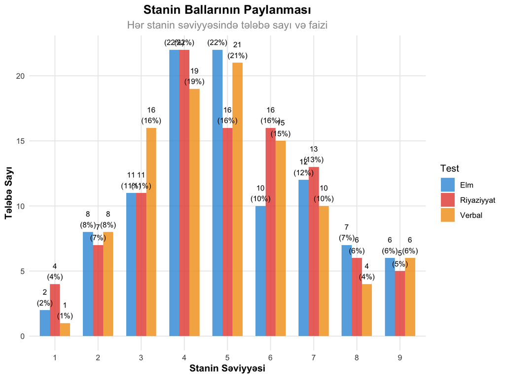

```r
# Stanin paylanması
stanine_distribution <- raw_scores %>%
  select(starts_with("Stanine_")) %>%
  pivot_longer(everything(), names_to = "Test", values_to = "Stanine") %>%
  mutate(Test = gsub("Stanine_", "", Test)) %>%
  count(Test, Stanine) %>%
  group_by(Test) %>%
  mutate(Faiz = round(n/sum(n)*100, 1))

ggplot(stanine_distribution, aes(x = factor(Stanine), y = n, fill = Test)) +
  geom_col(position = "dodge", alpha = 0.8, width = 0.7) +
  geom_text(aes(label = paste0(n, "\n(", Faiz, "%)")),
            position = position_dodge(width = 0.7), vjust = -0.3, size = 3) +
  scale_fill_manual(values = colors_basic[1:3]) +
  labs(title = "Stanin Ballarının Paylanması",
       subtitle = "Hər stanin səviyyəsində tələbə sayı və faizi",
       x = "Stanin Səviyyəsi", y = "Tələbə Sayı", fill = "Test") +
  theme_clean()
```

```r
# Konkret nümunələr
specific_examples$Stanine_Riyaziyyat <- calculate_stanine(c(specific_examples$Riyaziyyat, raw_scores$Riyaziyyat))[1:3]
specific_examples$Stanine_Verbal <- calculate_stanine(c(specific_examples$Verbal, raw_scores$Verbal))[1:3]
specific_examples$Stanine_Elm <- calculate_stanine(c(specific_examples$Elm, raw_scores$Elm))[1:3]

kable(specific_examples, caption = "Bütün Bal Növlərinin Müqayisəsi")
```

Bütün Bal Növlərinin Müqayisəsi

| Tələbə | Riyaziyyat | Verbal | Elm | Z_Riyaziyyat | Z_Verbal | Z_Elm | T_Riyaziyyat | T_Verbal | T_Elm | Stanine_Riyaziyyat | Stanine_Verbal | Stanine_Elm |
| --- | --- | --- | --- | --- | --- | --- | --- | --- | --- | --- | --- | --- |
| Ali | 82 | 580 | 31 | 0.54 | 0.84 | 0.40 | 55 | 58 | 54 | 6 | 7 | 6 |
| Ayşə | 78 | 510 | 26 | 0.17 | -0.01 | -0.48 | 52 | 50 | 45 | 5 | 5 | 4 |
| Elman | 85 | 625 | 34 | 0.81 | 1.39 | 0.93 | 58 | 64 | 59 | 7 | 8 | 7 |

```r
# Stanin interpretasiya rəhbəri
stanine_guide <- data.frame(
  Stanine_Qrupu = c("1-3", "4-6", "7-9"),
  Ümumi_Səviyyə = c("Aşağı", "Orta", "Yüksək"),
  Təxmini_Faiz = c("23%", "54%", "23%"),
  Praktik_Mənası = c("Dəstəyə ehtiyac", "Normal performans", "İrəliləmiş"),
  Tövsiyə = c("Əlavə yardım", "Standart proqram", "Zənginləşdirilmiş məzmun")
)

kable(stanine_guide, caption = "Stanin Qruplarının Praktik İnterpretasiyası")
```

Stanin Qruplarının Praktik İnterpretasiyası

| Stanine_Qrupu | Ümumi_Səviyyə | Təxmini_Faiz | Praktik_Mənası | Tövsiyə |
| --- | --- | --- | --- | --- |
| 1-3 | Aşağı | 23% | Dəstəyə ehtiyac | Əlavə yardım |
| 4-6 | Orta | 54% | Normal performans | Standart proqram |
| 7-9 | Yüksək | 23% | İrəliləmiş | Zənginləşdirilmiş məzmun |

# 5 Bal Sistemlərinin Müqayisəsi

## 5.1 Sistemlərin Xüsusiyyətlərinin Müqayisəsi

```r
# Müxtəlif bal sistemlərinin müqayisəsi
score_comparison <- data.frame(
  Aspekt = c("Sadəlik", "Dəqiqlik", "İnterpretasiya", "Hesablama", "Hədəf Kütlə", "Məlumat İtkisi"),
  Z_Bal = c("Çətin", "Çox yüksək", "Ekspert", "Dəqiq", "Statistik", "Yox"),
  T_Bal = c("Orta", "Yüksək", "Yaxşı", "Dəqiq", "Təhsil", "Minimal"),
  Stanine = c("Çox asan", "Aşağı", "Asan", "Təxmini", "Geniş", "Orta"),
  Ən_Yaxşısı = c("Stanine", "Z-Bal", "Stanine", "Z/T-Bal", "Stanine", "Z-Bal")
)

kable(score_comparison, caption = "Müxtəlif Bal Sistemlərinin Müqayisəsi")
```

Müxtəlif Bal Sistemlərinin Müqayisəsi

| Aspekt | Z_Bal | T_Bal | Stanine | Ən_Yaxşısı |
| --- | --- | --- | --- | --- |
| Sadəlik | Çətin | Orta | Çox asan | Stanine |
| Dəqiqlik | Çox yüksək | Yüksək | Aşağı | Z-Bal |
| İnterpretasiya | Ekspert | Yaxşı | Asan | Stanine |
| Hesablama | Dəqiq | Dəqiq | Təxmini | Z/T-Bal |
| Hədəf Kütlə | Statistik | Təhsil | Geniş | Stanine |
| Məlumat İtkisi | Yox | Minimal | Orta | Z-Bal |

```r
# Kontekstə görə tövsiyələr
context_recommendations <- data.frame(
  Kontekst = c("Elmi Tədqiqat", "Məktəb Hesabatı", "Valideyn Təqdimatı",
               "Diagnostik Qiymətləndirmə", "Qrup Təyinatı", "İstatistik Analiz"),
  Tövsiyə_Sistem = c("Z-Bal", "T-Bal", "Stanine", "T-Bal", "Stanine", "Z-Bal"),
  Səbəb = c("Riyazi dəqiqlik", "Müsbət dəyərlər", "Sadəlik",
            "İnterpretasiya", "Kateqorik bölgü", "Hesablama"),
  Alternativ = c("T-Bal", "Stanine", "T-Bal", "Stanine", "T-Bal", "T-Bal")
)

kable(context_recommendations, caption = "Kontekstə Görə Bal Sistemi Tövsiyələri")
```

Kontekstə Görə Bal Sistemi Tövsiyələri

| Kontekst | Tövsiyə_Sistem | Səbəb | Alternativ |
| --- | --- | --- | --- |
| Elmi Tədqiqat | Z-Bal | Riyazi dəqiqlik | T-Bal |
| Məktəb Hesabatı | T-Bal | Müsbət dəyərlər | Stanine |
| Valideyn Təqdimatı | Stanine | Sadəlik | T-Bal |
| Diagnostik Qiymətləndirmə | T-Bal | İnterpretasiya | Stanine |
| Qrup Təyinatı | Stanine | Kateqorik bölgü | T-Bal |
| İstatistik Analiz | Z-Bal | Hesablama | T-Bal |

# 6 R-da Bal Çevrilməsi Funksiyaları

## 6.1 Universal Çevrilmə Funksiyası

```r
# Hərtərəfli bal çevrilməsi funksiyası
comprehensive_score_conversion <- function(raw_scores,
                                         target_scale = "T",
                                         reference_mean = NULL,
                                         reference_sd = NULL) {

  # Referans parametrlər
  if(is.null(reference_mean)) reference_mean <- mean(raw_scores, na.rm = TRUE)
  if(is.null(reference_sd)) reference_sd <- sd(raw_scores, na.rm = TRUE)

  # Z-bal hesabla
  z_scores <- (raw_scores - reference_mean) / reference_sd

  # Hədəf miqyasa çevir
  converted_scores <- switch(target_scale,
    "Z" = z_scores,
    "T" = 50 + 10 * z_scores,
    "Stanine" = {
      cuts <- c(-Inf, -1.75, -1.25, -0.75, -0.25, 0.25, 0.75, 1.25, 1.75, Inf)
      as.numeric(cut(z_scores, breaks = cuts, labels = 1:9, include.lowest = TRUE))
    },
    "IQ" = 100 + 15 * z_scores,
    "SAT" = 500 + 100 * z_scores,
    z_scores  # Default Z-bal
  )

  # Nəticələri formatla
  if(target_scale == "Stanine") {
    converted_scores <- round(converted_scores, 0)
  } else if(target_scale %in% c("T", "IQ", "SAT")) {
    converted_scores <- round(converted_scores, 0)
  } else {
    converted_scores <- round(converted_scores, 2)
  }

  return(list(
    original_scores = raw_scores,
    z_scores = round(z_scores, 2),
    converted_scores = converted_scores,
    scale_type = target_scale,
    reference_stats = list(mean = reference_mean, sd = reference_sd)
  ))
}

# Müxtəlif miqyaslar üçün nümunə
sample_scores <- c(78, 85, 92, 67, 73, 89, 76, 82, 95, 71)

# Bütün miqyaslara çevrilmə
all_scales <- data.frame(
  Xam_Bal = sample_scores,
  Z_Bal = comprehensive_score_conversion(sample_scores, "Z")$converted_scores,
  T_Bal = comprehensive_score_conversion(sample_scores, "T")$converted_scores,
  Stanine = comprehensive_score_conversion(sample_scores, "Stanine")$converted_scores,
  IQ_Miqyası = comprehensive_score_conversion(sample_scores, "IQ")$converted_scores,
  SAT_Miqyası = comprehensive_score_conversion(sample_scores, "SAT")$converted_scores
)

kable(all_scales, caption = "Müxtəlif Miqyaslara Çevrilmə Nümunəsi")
```

Müxtəlif Miqyaslara Çevrilmə Nümunəsi

| Xam_Bal | Z_Bal | T_Bal | Stanine | IQ_Miqyası | SAT_Miqyası |
| --- | --- | --- | --- | --- | --- |
| 78 | -0.30 | 47 | 4 | 96 | 470 |
| 85 | 0.45 | 54 | 6 | 107 | 545 |
| 92 | 1.19 | 62 | 7 | 118 | 619 |
| 67 | -1.47 | 35 | 2 | 78 | 353 |
| 73 | -0.83 | 42 | 3 | 88 | 417 |
| 89 | 0.87 | 59 | 7 | 113 | 587 |
| 76 | -0.51 | 45 | 4 | 92 | 449 |
| 82 | 0.13 | 51 | 5 | 102 | 513 |
| 95 | 1.51 | 65 | 8 | 123 | 651 |
| 71 | -1.04 | 40 | 3 | 84 | 396 |

```r
# Miqyas xüsusiyyətləri
scale_properties <- data.frame(
  Miqyas = c("Z-Bal", "T-Bal", "Stanine", "IQ", "SAT"),
  Orta = c(0, 50, 5, 100, 500),
  SD = c(1, 10, 2, 15, 100),
  Tipik_Aralıq = c("-3 to +3", "20 to 80", "1 to 9", "55 to 145", "200 to 800"),
  İstifadə_Sahəsi = c("Statistika", "Təhsil", "Psixologiya", "Zəka testləri", "Kollec qəbulu")
)

kable(scale_properties, caption = "Müxtəlif Standart Miqyasların Xüsusiyyətləri")
```

Müxtəlif Standart Miqyasların Xüsusiyyətləri

| Miqyas | Orta | SD | Tipik_Aralıq | İstifadə_Sahəsi |
| --- | --- | --- | --- | --- |
| Z-Bal | 0 | 1 | -3 to +3 | Statistika |
| T-Bal | 50 | 10 | 20 to 80 | Təhsil |
| Stanine | 5 | 2 | 1 to 9 | Psixologiya |
| IQ | 100 | 15 | 55 to 145 | Zəka testləri |
| SAT | 500 | 100 | 200 to 800 | Kollec qəbulu |

## 6.2 Toplu Çevrilmə və Profil Analizi

```r
# Toplu çevrilmə funksiyası
batch_score_conversion <- function(data, score_columns, target_scales = c("Z", "T", "Stanine")) {

  results <- data

  for(col in score_columns) {
    for(scale in target_scales) {
      new_col_name <- paste0(col, "_", scale)
      conversion_result <- comprehensive_score_conversion(data[[col]], scale)
      results[[new_col_name]] <- conversion_result$converted_scores
    }
  }

  return(results)
}

# Nümunə məlumat
sample_data <- data.frame(
  Student_ID = 1:20,
  Math_Score = round(rnorm(20, 75, 12), 1),
  Reading_Score = round(rnorm(20, 68, 15), 1),
  Science_Score = round(rnorm(20, 82, 10), 1)
)

# Toplu çevrilmə
converted_data <- batch_score_conversion(sample_data,
                                       c("Math_Score", "Reading_Score", "Science_Score"))

# İlk bir neçə sətiri göstər
kable(head(converted_data[, 1:10], 8), caption = "Toplu Çevrilmə Nəticələri", digits = 1)
```

Toplu Çevrilmə Nəticələri

| Student_ID | Math_Score | Reading_Score | Science_Score | Math_Score_Z | Math_Score_T | Math_Score_Stanine | Reading_Score_Z | Reading_Score_T | Reading_Score_Stanine |
| --- | --- | --- | --- | --- | --- | --- | --- | --- | --- |
| 1 | 66.4 | 71.6 | 88.2 | -0.6 | 44 | 4 | 0.2 | 52 | 5 |
| 2 | 66.0 | 86.3 | 91.6 | -0.6 | 44 | 4 | 1.2 | 62 | 7 |
| 3 | 63.7 | 47.9 | 98.7 | -0.8 | 42 | 3 | -1.4 | 36 | 2 |
| 4 | 62.4 | 77.9 | 82.6 | -0.9 | 41 | 3 | 0.6 | 56 | 6 |
| 5 | 69.8 | 60.2 | 81.5 | -0.3 | 47 | 4 | -0.6 | 44 | 4 |
| 6 | 79.0 | 78.3 | 64.5 | 0.3 | 53 | 6 | 0.6 | 56 | 6 |
| 7 | 50.8 | 67.1 | 83.0 | -1.7 | 33 | 2 | -0.1 | 49 | 5 |
| 8 | 77.5 | 77.5 | 76.3 | 0.2 | 52 | 5 | 0.6 | 56 | 6 |

[figure not shown]

```r
# Tələbə profil yaratma funksiyası
create_student_profile <- function(data, student_id, score_cols) {
  student_data <- data[data$Student_ID == student_id, ]

  # T-balları topla
  t_scores <- c()
  test_names <- c()

  for(col in score_cols) {
    t_col <- paste0(col, "_T")
    t_scores <- c(t_scores, student_data[[t_col]])
    test_names <- c(test_names, gsub("_Score", "", col))
  }

  profile_data <- data.frame(
    Test = test_names,
    T_Score = t_scores
  )

  ggplot(profile_data, aes(x = Test, y = T_Score)) +
    geom_col(fill = colors_basic[1], alpha = 0.7, width = 0.6) +
    geom_hline(yintercept = 50, linetype = "dashed", color = "red") +
    geom_hline(yintercept = c(40, 60), linetype = "dotted", alpha = 0.6) +
    geom_text(aes(label = T_Score), vjust = -0.3, fontface = "bold") +
    labs(title = paste("Tələbə", student_id, "üçün T-Bal Profili"),
         subtitle = "Qırmızı xətt: orta (T=50), Nöqtəli: ±1 SD",
         x = "Test Sahəsi", y = "T-Bal") +
    theme_clean() +
    ylim(20, 80)
}

# Nümunə profil
create_student_profile(converted_data, 5, c("Math_Score", "Reading_Score", "Science_Score"))
```

```r
# Statistik xülasə
summary_stats <- converted_data %>%
  summarise(
    N = n(),
    Math_T_Orta = round(mean(Math_Score_T), 1),
    Reading_T_Orta = round(mean(Reading_Score_T), 1),
    Science_T_Orta = round(mean(Science_Score_T), 1),
    Math_T_SD = round(sd(Math_Score_T), 1),
    Reading_T_SD = round(sd(Reading_Score_T), 1),
    Science_T_SD = round(sd(Science_Score_T), 1)
  )

kable(summary_stats, caption = "T-Balların Statistik Xülasəsi")
```

T-Balların Statistik Xülasəsi

| N | Math_T_Orta | Reading_T_Orta | Science_T_Orta | Math_T_SD | Reading_T_SD | Science_T_SD |
| --- | --- | --- | --- | --- | --- | --- |
| 20 | 49.9 | 50 | 50 | 9.9 | 10 | 10 |

# 7 Dərsin Xülasəsi

## 7.1 Əsas Nəticələr

**Standart Balların Mahiyyəti:** - ✓ **Standartlaşma zərurəti** - müxtəlif testlərin müqayisəsi üçün - ✓ **Z-bal (Z = (X-M)/SD)** - ən fundamental standart bal - ✓ **Normal paylanma əsası** - statistik interpretasiya imkanı

**Praktik Bal Sistemləri:** - ✓ **T-bal (T = 50 + 10Z)** - təhsildə ən geniş istifadə - ✓ **Stanine (1-9)** - sadəlik və kategorik interpretasiya - ✓ **Kontekstə uyğun seçim** - hədəf kütlə və məqsədə görə

**R Tətbiqi və Avtomatlaşma:** - ✓ Hərtərəfli çevrilmə funksiyaları - ✓ Toplu işləmə və hesabat generasiyası - ✓ İnteraktiv profil analizləri

# 8 Ev Tapşırığı

## 8.1 Tapşırıq 1: Nəzəri Hissə (25 xal)

1. **Standartlaşmanın əhəmiyyəti** nədir? Z-bal, T-bal və Stanin ballarının hər birinin hansı vəziyyətlərdə üstünlüyü var? (300 söz)
2. **Bal sistemi seçimi** necə edilməlidir? Müxtəlif kontekstlər (valideyn hesabatı, elmi tədqiqat, məktəb administrasiyası) üçün tövsiyələrinizi əsaslandırın. (250 söz)
3. **Normal paylanma fərziyyəsi** standart ballar üçün niyə vacibdir? Bu fərziyyə pozulduqda nə baş verir? (200 söz)

## 8.2 Tapşırıq 2: R Praktik Analizi (50 xal)

```r
# Bal çevrilməsi tapşırığı
set.seed(sizin_tələbə_nömrəniz)

# Verilmiş test nəticələri (25 tələbə, 4 test)
n_students <- 25
test_data <- data.frame(
  Student_ID = 1:n_students,
  Riyaziyyat = round(rnorm(n_students, 78, 14), 1),
  İngilis = round(rnorm(n_students, 65, 18), 1),
  Elm = round(rnorm(n_students, 82, 12), 1),
  Tarix = round(rnorm(n_students, 71, 16), 1)
)

# TAPŞİRIQLAR:
# 1. Hər test üçün Z-bal, T-bal və Stanine hesablayın
# 2. Ən yüksək və ən aşağı performanslı tələbələri müəyyənləşdirin
# 3. Hər tələbə üçün orta T-bal hesablayın
# 4. Qrup profili (orta performans) yaradın
# 5. Müxtəlif bal sistemləri arasında korrelyasiya hesablayın

# HƏLL STRUKTURU:
score_conversion_function <- function(raw_scores, target_scale) {
  # Z-bal hesabla
  z_scores <- (raw_scores - mean(raw_scores)) / sd(raw_scores)

  # Hədəf miqyasa çevir
  if(target_scale == "Z") {
    return(round(z_scores, 2))
  } else if(target_scale == "T") {
    return(round(50 + 10 * z_scores, 0))
  } else if(target_scale == "Stanine") {
    cuts <- c(-Inf, -1.75, -1.25, -0.75, -0.25, 0.25, 0.75, 1.25, 1.75, Inf)
    return(as.numeric(cut(z_scores, breaks = cuts, labels = 1:9, include.lowest = TRUE)))
  }
}

# CAVABLARINIZI YAZIN və çevrilmə əməliyyatlarını aparın
print("Ən yüksək performanslı tələbə:")
print("Ən aşağı performanslı tələbə:")
print("Orta qrup T-balı:")
print("Bal sistemləri arası korrelyasiya:")
```

## 8.3 Tapşırıq 3: Praktik Tətbiq Planı (25 xal)

Aşağıdakı ssenari üçün bal sistemi seçimi və tətbiq planı hazırlayın:

**Ssenari:** Regional təhsil idarəsi 5000 şagird üçün standartlaşdırılmış test nəticələrini müxtəlif maraqdar tərəflərə (valideynlər, müəllimlər, direktorlar, nazirlik) təqdim etməlidir.

**Tələblər:**

1. **Hədəf kütlə analizi** (200 söz)
   - Hər qrup üçün ehtiyac və gözlənti
   - Riyazi bilik səviyyəsi qiymətləndirməsi
   - İnterpretasiya çətinliyi dərəcəsi
2. **Bal sistemi strategiyası** (250 söz)
   - Hər qrup üçün tövsiyə olunan bal sistemi
   - Çevrilmə və təqdimat strategiyası
   - Kombine yanaşma planı
3. **Tətbiq və kommunikasiya** (200 söz)
   - Hər bal sistemi üçün izah materialları
   - Təlim proqramı planı
   - Keyfiyyət nəzarəti protokolu

# 9 Növbəti Dərslərə Hazırlıq

## 9.1 Dərs 17: “Percentil Ranklar və Normalar”

Növbəti dərsdə öyrənəcəklər:

- ✓ Percentil rankların hesablanması və interpretasiyası
- ✓ Norma qrupları və referans populyasiyalar
- ✓ Yaş və sinif normları
- ✓ Lokal vs milli normalar

## 9.2 Dərs 18: “Test Normalarının Qurulması”

Sonrakı mövzular:

- ✓ Norma toplama dizaynı və metodologiyası
- ✓ Təmsili örnəkləmə strategiyaları
- ✓ Demografik çəki və düzəlişlər
- ✓ Norma cədvəllərinin yaradılması

# 10 Əlavə Tədqiqat Materialları

## 10.1 Əsas Ədəbiyyat

**Məcburi oxu:** - Cronbach, L.J. (1990). *Essentials of Psychological Testing*. Fəsil 4: “Norms and the Meaning of Scores” - Anastasi, A., & Urbina, S. (1997). *Psychological Testing*. Fəsil 3: “Norms and the Meaning of Scores”

**Tövsiyə olunan:** - Angoff, W.H. (1984). *Scales, Norms, and Equivalent Scores* - Petersen, N.S., Kolen, M.J., & Hoover, H.D. (1989). “Scaling, norming, and equating”

## 10.2 Online Resurslar

**R Paketləri:** - `base R` - əsas statistik funksiyalar - `psych` - psixometrik transformasiyalar - `scales` - miqyas çevrilmələri

**Kalkulyatorlar:** - [Z-Score Calculator](https://www.calculator.net/z-score-calculator.html) - [T-Score Converter](https://www.rapidtables.com/calc/math/standard-score-calculator.html)

## 10.3 Təbriklər!

Xam balları müxtəlif standart bal sistemlərinə çevirmə bacarığını əldə etdiniz! İndi testlərin nəticələrini daha məna kəsb edən formada təqdim edə bilirsiniz.

**Növbəti dərsdə percentil ranklar və norma sistemlərini öyrənəcəksiniz! 📊**

*Bu dərs klassik test nəzəriyyəsi və psixometrik standartlaşma metodlarına əsaslanır.*

**Son yenilənmə:** 2025-07-18 | **Versiya:** 1.0